# Time and motion quantitative analysis - final

Stefanie Meliss

2026-07-03

Overview of TimeCaT observation entries by dimension and data processing step

| name | Interactions | Individual | Location | Total |
| --- | --- | --- | --- | --- |
| raw | 5786 | 2968 | 1259 | 10013 |
| error | 99 | 15 | 23 | 137 |
| unique | 5687 | 2953 | 1236 | 9876 |
| Coded | 4719 (83%) | 1874 (63.5%) | 1209 (97.8%) | 7802 (79%) |
| None | 968 (17%) | 1079 (36.5%) | 27 (2.2%) | 2074 (21%) |
| irreg | 23 (0.4%) | 3 (0.1%) | 9 (0.7%) | 35 (0.4%) |
| unacc | 597 | 16 | 112 | 725 |

*Note.* Data from all N = 18 was combined.

# Timeline plots

```
##
## Fig 2
```

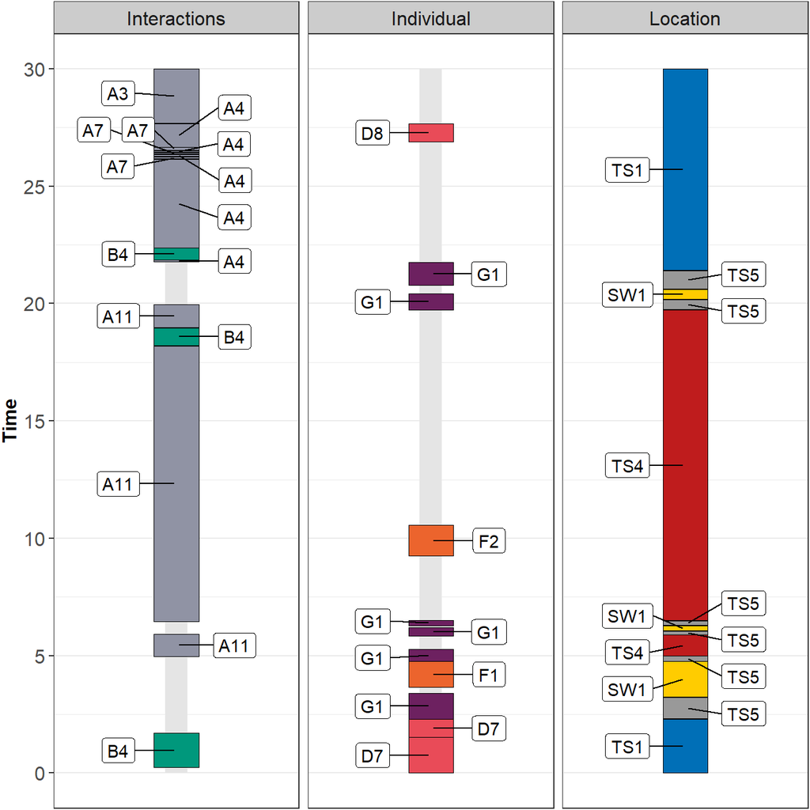

```
##
## Fig 5
```

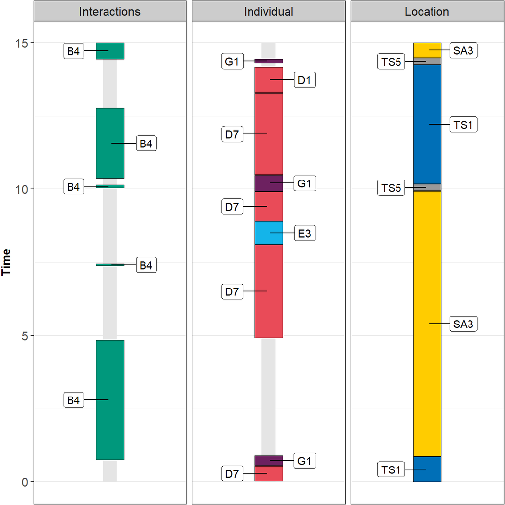

```
##
## Fig 9
```

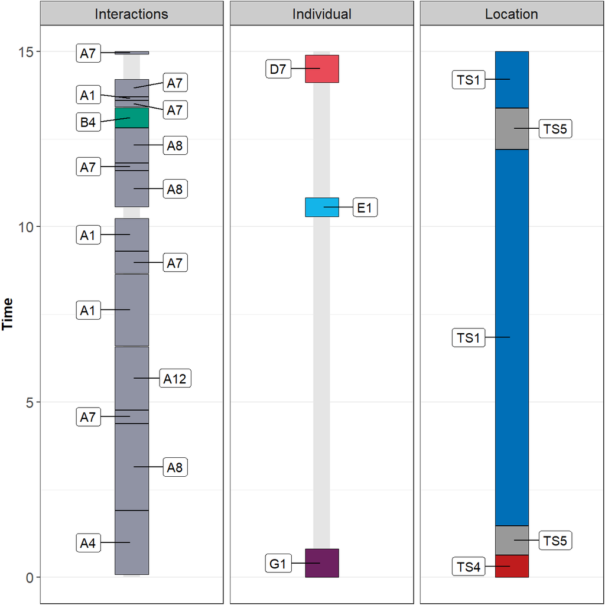

```
##
## Fig 10
```

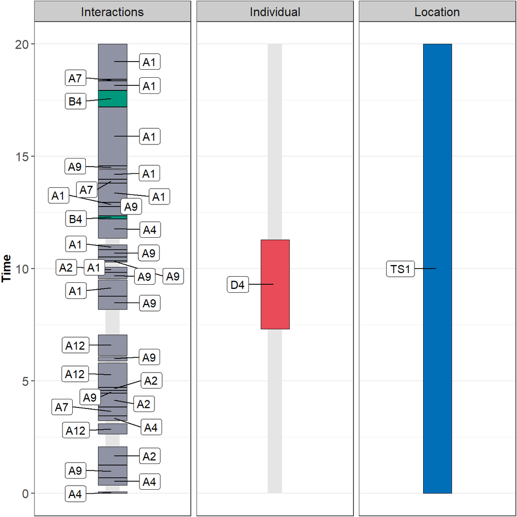

```
##
## Fig 11
```

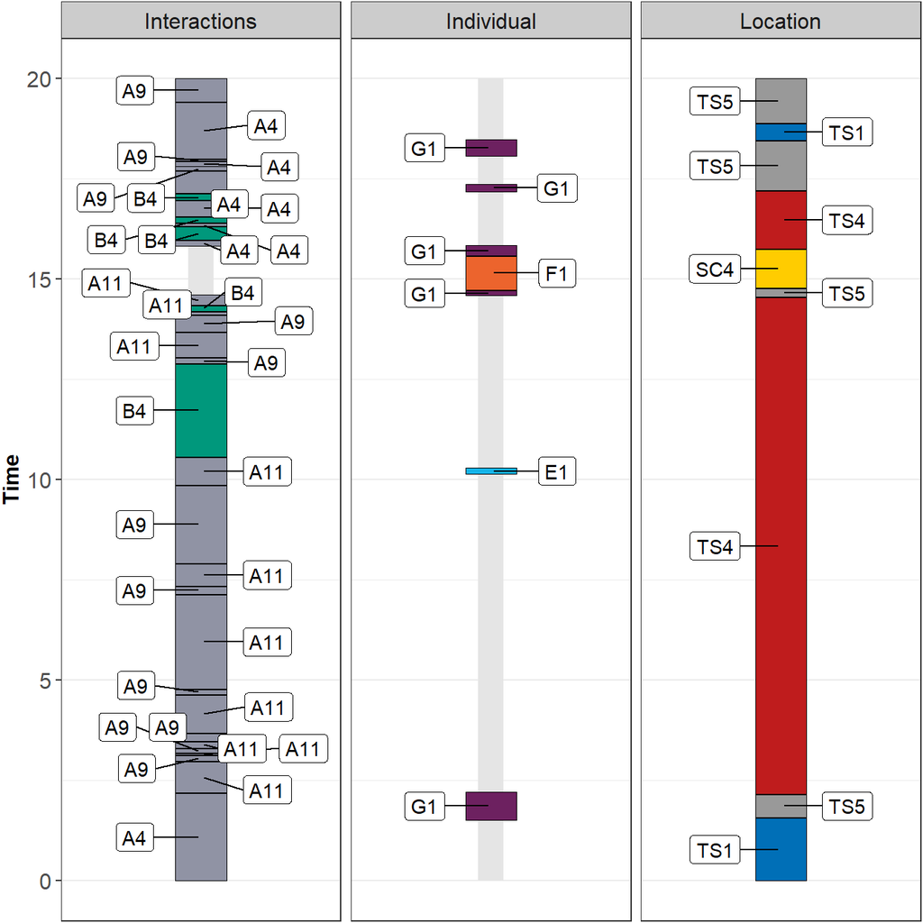

```
##
## Fig 12
```

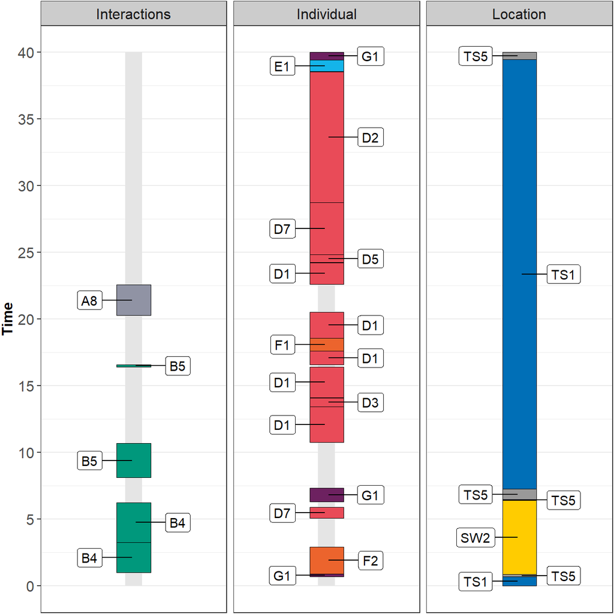

```
##
## Fig 13
```

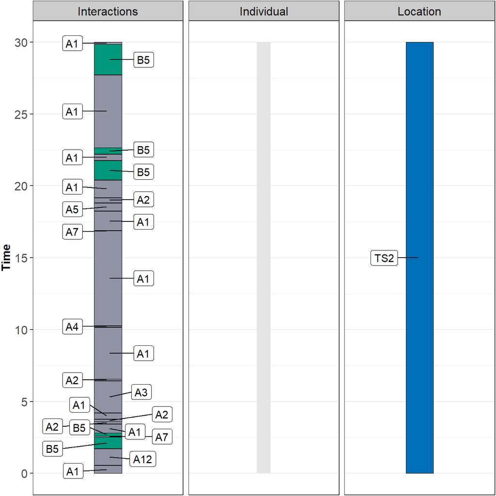

# Observed hours and evening hours

Average length of day observed

| Phase | n_dur | n_obs_dur | mean_dur | sd_dur | min_dur | max_dur | SE_dur |
| --- | --- | --- | --- | --- | --- | --- | --- |
| Whole sample | 18 | 18 | 8.64 | 0.61 | 7.88 | 9.90 | 0.14 |
| Primary | 9 | 9 | 8.69 | 0.57 | 7.88 | 9.83 | 0.19 |
| Secondary | 9 | 9 | 8.59 | 0.67 | 7.96 | 9.90 | 0.22 |

*Note.* Results are reported in hours.

Observations by domain

| Phase | Dimension | Total counts n_count | Total counts n_obs_count | Total counts mean_count | Total counts sd_count | Total counts min_count | Total counts max_count | Total counts SE_count | Total minutes n_mins | Total minutes n_obs_mins | Total minutes mean_mins | Total minutes sd_mins | Total minutes min_mins | Total minutes max_mins | Total minutes SE_mins | Total hours n_hrs | Total hours n_obs_hrs | Total hours mean_hrs | Total hours sd_hrs | Total hours min_hrs | Total hours max_hrs | Total hours SE_hrs |
| --- | --- | --- | --- | --- | --- | --- | --- | --- | --- | --- | --- | --- | --- | --- | --- | --- | --- | --- | --- | --- | --- | --- |
| Whole sample | Interactions | 18 | 18 | 262.17 | 93.56 | 126 | 451 | 22.05 | 18 | 18 | 397.58 | 53.05 | 291.22 | 506.32 | 12.50 | 18 | 18 | 6.63 | 0.88 | 4.85 | 8.44 | 0.21 |
| Whole sample | Individual | 18 | 18 | 104.11 | 36.98 | 47 | 149 | 8.72 | 18 | 18 | 165.32 | 46.05 | 88.62 | 264.32 | 10.85 | 18 | 18 | 2.76 | 0.77 | 1.48 | 4.41 | 0.18 |
| Whole sample | Location | 18 | 18 | 67.17 | 20.54 | 41 | 108 | 4.84 | 18 | 18 | 514.23 | 38.79 | 463.70 | 593.43 | 9.14 | 18 | 18 | 8.57 | 0.65 | 7.73 | 9.89 | 0.15 |
| Whole sample | Tasks | 18 | 18 | 366.28 | 120.18 | 181 | 591 | 28.33 | 18 | 18 | 562.90 | 59.95 | 490.85 | 690.55 | 14.13 | 18 | 18 | 9.38 | 1.00 | 8.18 | 11.51 | 0.24 |
| Primary | Interactions | 9 | 9 | 294.33 | 90.58 | 148 | 451 | 30.19 | 9 | 9 | 420.29 | 47.11 | 359.05 | 506.32 | 15.70 | 9 | 9 | 7.00 | 0.79 | 5.98 | 8.44 | 0.26 |
| Primary | Individual | 9 | 9 | 109.11 | 34.56 | 50 | 142 | 11.52 | 9 | 9 | 152.04 | 33.49 | 88.62 | 194.17 | 11.16 | 9 | 9 | 2.53 | 0.56 | 1.48 | 3.24 | 0.19 |
| Primary | Location | 9 | 9 | 69.78 | 16.05 | 53 | 108 | 5.35 | 9 | 9 | 520.33 | 34.85 | 470.27 | 589.00 | 11.62 | 9 | 9 | 8.67 | 0.58 | 7.84 | 9.82 | 0.19 |
| Primary | Tasks | 9 | 9 | 403.44 | 115.93 | 231 | 591 | 38.64 | 9 | 9 | 572.32 | 56.71 | 497.93 | 668.15 | 18.90 | 9 | 9 | 9.54 | 0.95 | 8.30 | 11.14 | 0.32 |
| Secondary | Interactions | 9 | 9 | 230.00 | 89.81 | 126 | 409 | 29.94 | 9 | 9 | 374.88 | 51.00 | 291.22 | 450.13 | 17.00 | 9 | 9 | 6.25 | 0.85 | 4.85 | 7.50 | 0.28 |
| Secondary | Individual | 9 | 9 | 99.11 | 40.68 | 47 | 149 | 13.56 | 9 | 9 | 178.60 | 54.66 | 90.45 | 264.32 | 18.22 | 9 | 9 | 2.98 | 0.91 | 1.51 | 4.41 | 0.30 |
| Secondary | Location | 9 | 9 | 64.56 | 24.98 | 41 | 100 | 8.33 | 9 | 9 | 508.13 | 43.57 | 463.70 | 593.43 | 14.52 | 9 | 9 | 8.47 | 0.73 | 7.73 | 9.89 | 0.24 |
| Secondary | Tasks | 9 | 9 | 329.11 | 118.93 | 181 | 558 | 39.64 | 9 | 9 | 553.48 | 64.97 | 490.85 | 690.55 | 21.66 | 9 | 9 | 9.22 | 1.08 | 8.18 | 11.51 | 0.36 |

*Note.* Results are reported in minutes and hours.

### **Table**

### *Descriptive statistics on the observed hours in addition to self-reported additional hours worked after observation before the next working day*

Observed hours in addition to evening working hours

| Working hours | Whole sample (N = 18) | Primary teachers (n = 9) | Secondary teachers (n = 9) |
| --- | --- | --- | --- |
| Observed | 8.64 (0.61) [7.88; 9.9] | 8.69 (0.57) [7.88; 9.83] | 8.59 (0.67) [7.96; 9.9] |
| Work before next working day | 1.08 (1.25) [0; 5] | 0.56 (0.77) [0; 2.42] | 1.6 (1.46) [0; 5] |
| Total | 9.72 (1.45) [7.88; 14.42] | 9.24 (1) [7.88; 11.22] | 10.19 (1.72) [8.58; 14.42] |

*Note.* Results are reported in hours.

# Stakeholder interactions

### **Figure**

### *Overview of average total minutes teachers spent engaging with stakeholders and teaching over the observed day*

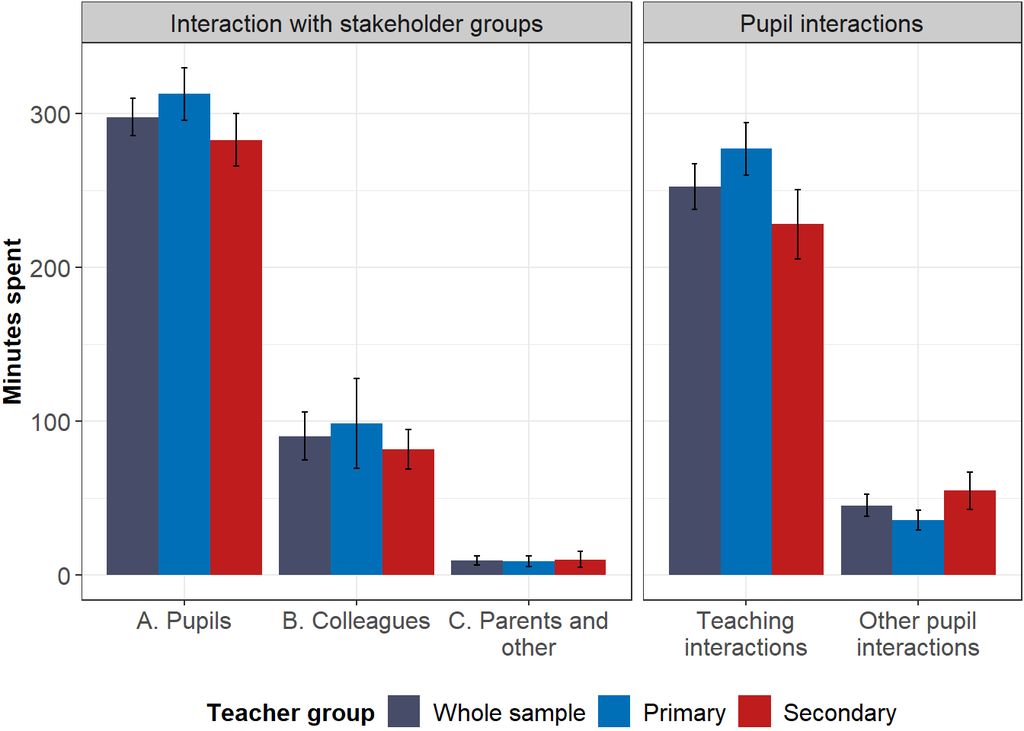

*Note.* For each teacher, total minutes spent engaging with stakeholders and teaching were summed. Summary statistics were then calculated across teachers. Bars represent M whereas error bars represent SE.

### **Figure**

### *Breakdown of teacher-aggregated total minutes spent in stakeholder interactions*

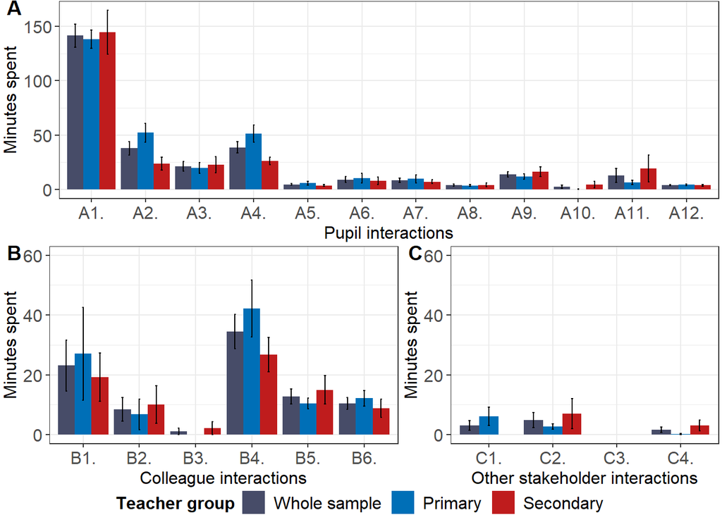

*Note.* For each teacher, total minutes spent engaging in various stakeholder interactions with pupils (A), colleagues (B) and other stakeholders (C) were summed. Summary statistics were then calculated across teachers. Bars represent M whereas error bars represent SE.

### **Table**

### *Descriptive statistics on the duration of stakeholder interactions*

| Stakeholder interaction | Whole sample (N = 18) | Primary teachers (n = 9) | Secondary teachers (n = 9) |
| --- | --- | --- | --- |
| Pupil interactions |  |  |  |
| A1. Teaching curriculum content, providing lesson instructions and overseeing pupil work | 141.4 (45.13) [64.27; 234.92] | 138.17 (25.48) [100.38; 169.92] | 144.63 (60.46) [64.27; 234.92] |
| A2. Answering pupil questions and providing one-to-one support | 37.87 (25.99) [1.48; 102.07] | 52.18 (25.86) [16.62; 102.07] | 23.57 (17.51) [1.48; 54.42] |
| A3. Whole class feedback | 21.21 (18.36) [2.23; 63.32] | 19.8 (14.79) [3.43; 46.12] | 22.62 (22.2) [2.23; 63.32] |
| A4. Observing and managing pupil transitions in/out of class and within class | 38.58 (21.72) [9.47; 95.12] | 51.22 (23.09) [26.9; 95.12] | 25.93 (10.49) [9.47; 38.52] |
| A5. Handing out resources | 4.61 (3.74) [0.62; 12.47] | 5.66 (4.79) [0.97; 12.47] | 3.56 (2.09) [0.62; 6.65] |
| A6. Form or class pastoral time | 9 (11.76) [0; 36.75] | 10.16 (13.47) [0; 36.75] | 7.84 (10.46) [0; 22.52] |
| A7. Managing pupil interruptions, addressing inappropriate behaviour and enforcing school rules | 8.41 (8.54) [1.22; 36.42] | 9.75 (11.07) [1.43; 36.42] | 7.06 (5.33) [1.22; 16] |
| A8. Pastoral support | 3.81 (3.63) [0; 14.18] | 3.52 (1.96) [1; 7.12] | 4.09 (4.89) [0; 14.18] |
| A9. Pupil(s) informal interaction face-to-face | 13.89 (10.85) [0.4; 36.45] | 11.59 (7.37) [1.57; 22.23] | 16.19 (13.57) [0.4; 36.45] |
| A10. Attending or delivering assembly | 2.23 (6.32) [0; 23.08] | 0.21 (0.63) [0; 1.88] | 4.26 (8.67) [0; 23.08] |
| A11. School duty | 12.88 (26.59) [0; 113.5] | 6.35 (5.66) [0; 16.37] | 19.41 (37.07) [0; 113.5] |
| A12. Pupil register | 4.03 (1.97) [0; 7.3] | 4.24 (1.86) [1.13; 7.3] | 3.81 (2.16) [0; 6.85] |
| Teaching interactions | 252.67 (63.46) [118.27; 339.27] | 277.2 (51.03) [185.83; 338.05] | 228.15 (67.83) [118.27; 339.27] |
| Other pupil interactions | 45.25 (30.04) [6.17; 130.13] | 35.66 (19.61) [6.17; 75.63] | 54.83 (36.42) [10.22; 130.13] |
| A. Pupils | 297.92 (52.12) [192; 369.87] | 312.86 (51.36) [192; 359.63] | 282.99 (51.3) [217.47; 369.87] |
| Colleague interactions |  |  |  |
| B1. Organised meeting between colleagues | 23.11 (36.27) [0; 140.28] | 27.04 (46.68) [0; 140.28] | 19.19 (24.13) [0; 54.47] |
| B2. Mentoring: providing or receiving formal, scheduled professional guidance | 8.39 (16.68) [0; 46.28] | 6.73 (15.14) [0; 44.53] | 10.06 (18.87) [0; 46.28] |
| B3. Co-planning with colleague(s) | 1.07 (4.52) [0; 19.18] | 0 (0) [0; 0] | 2.13 (6.39) [0; 19.18] |
| B4. Colleague(s) work-related interaction face-to-face | 34.48 (24.18) [5.67; 106.22] | 42.21 (28.47) [16.6; 106.22] | 26.74 (17.26) [5.67; 60.42] |
| B5. Colleague(s) interaction via technology | 12.67 (10.7) [0; 42.83] | 10.38 (5.27) [2.5; 20.2] | 14.96 (14.27) [0; 42.83] |
| B6. Colleague(s) informal interaction face-to-face | 10.44 (8.58) [0; 27.47] | 12.13 (7.94) [1.02; 24.3] | 8.75 (9.32) [0; 27.47] |
| B. Colleagues | 90.16 (66.22) [26.1; 312.2] | 98.49 (87.6) [36.78; 312.2] | 81.83 (38.58) [26.1; 163.03] |
| Parent and other stakeholder interactions |  |  |  |
| C1. Parent or carer interaction face-to-face | 3.07 (7.02) [0; 29.38] | 6.14 (9.14) [0; 29.38] | 0 (0) [0; 0] |
| C2. Parent or carer interaction via technology | 4.8 (10.89) [0; 45.8] | 2.64 (2.72) [0; 7.88] | 6.97 (15.31) [0; 45.8] |
| C3. Parent or carer review of records | 0 (0) [0; 0] | 0 (0) [0; 0] | 0 (0) [0; 0] |
| C4. Other external stakeholder(s) interaction | 1.63 (4.03) [0; 14.8] | 0.16 (0.48) [0; 1.45] | 3.1 (5.43) [0; 14.8] |
| C. Parents and other | 9.5 (12.83) [0; 47.12] | 8.94 (10.59) [0; 35.05] | 10.06 (15.39) [0; 47.12] |

### **Table**

### *Descriptive statistics on the frequency of stakeholder interactions*

| Stakeholder interaction | Whole sample (N = 18) | Primary teachers (n = 9) | Secondary teachers (n = 9) |
| --- | --- | --- | --- |
| Pupil interactions |  |  |  |
| A1. Teaching curriculum content, providing lesson instructions and overseeing pupil work | 51.78 (25.29) [8; 102] | 55.78 (22.97) [33; 102] | 47.78 (28.19) [8; 100] |
| A2. Answering pupil questions and providing one-to-one support | 35.28 (26.83) [3; 126] | 42.22 (33.57) [12; 126] | 28.33 (17.15) [3; 58] |
| A3. Whole class feedback | 8.33 (5.55) [1; 20] | 9.22 (5.74) [1; 20] | 7.44 (5.55) [1; 15] |
| A4. Observing and managing pupil transitions in/out of class and within class | 30.78 (18.48) [9; 71] | 44.22 (16.7) [25; 71] | 17.33 (6.3) [9; 27] |
| A5. Handing out resources | 6.83 (4.83) [1; 19] | 6.44 (5.17) [1; 19] | 7.22 (4.74) [2; 16] |
| A6. Form or class pastoral time | 3.67 (5.51) [0; 19] | 5.44 (7.07) [0; 19] | 1.89 (2.71) [0; 8] |
| A7. Managing pupil interruptions, addressing inappropriate behaviour and enforcing school rules | 24.56 (13.32) [9; 48] | 25 (13.18) [10; 48] | 24.11 (14.24) [9; 42] |
| A8. Pastoral support | 3.39 (2.77) [0; 8] | 3.67 (2.45) [1; 8] | 3.11 (3.18) [0; 8] |
| A9. Pupil(s) informal interaction face-to-face | 27.11 (17.43) [1; 68] | 25.11 (12.55) [6; 40] | 29.11 (21.88) [1; 68] |
| A10. Attending or delivering assembly | 0.83 (2.43) [0; 10] | 0.22 (0.67) [0; 2] | 1.44 (3.36) [0; 10] |
| A11. School duty | 4.89 (7.21) [0; 27] | 3.89 (4.34) [0; 11] | 5.89 (9.45) [0; 27] |
| A12. Pupil register | 4.22 (2.78) [0; 11] | 3.11 (1.27) [1; 5] | 5.33 (3.46) [0; 11] |
| Teaching interactions | 136.67 (67.19) [23; 311] | 163.33 (72.9) [86; 311] | 110 (51.76) [23; 188] |
| Other pupil interactions | 65 (27.66) [22; 104] | 61 (25.71) [22; 94] | 69 (30.47) [25; 104] |
| A. Pupils | 201.67 (79.94) [96; 368] | 224.33 (86.63) [113; 368] | 179 (70.14) [96; 292] |
| Colleague interactions |  |  |  |
| B1. Organised meeting between colleagues | 1 (1.33) [0; 5] | 0.89 (1.62) [0; 5] | 1.11 (1.05) [0; 3] |
| B2. Mentoring: providing or receiving formal, scheduled professional guidance | 1.94 (4.33) [0; 15] | 1.67 (4) [0; 12] | 2.22 (4.87) [0; 15] |
| B3. Co-planning with colleague(s) | 0.22 (0.94) [0; 4] | 0 (0) [0; 0] | 0.44 (1.33) [0; 4] |
| B4. Colleague(s) work-related interaction face-to-face | 35.17 (22.08) [9; 99] | 42.67 (25.44) [21; 99] | 27.67 (16.19) [9; 55] |
| B5. Colleague(s) interaction via technology | 11.94 (12.37) [0; 51] | 12.33 (9.38) [1; 32] | 11.56 (15.4) [0; 51] |
| B6. Colleague(s) informal interaction face-to-face | 5.11 (3.86) [0; 14] | 5.44 (3.24) [2; 12] | 4.78 (4.58) [0; 14] |
| B. Colleagues | 55.39 (30.76) [20; 132] | 63 (34.08) [28; 132] | 47.78 (26.8) [20; 100] |
| Parent and other stakeholder interactions |  |  |  |
| C1. Parent or carer interaction face-to-face | 2.56 (4.64) [0; 18] | 5.11 (5.58) [0; 18] | 0 (0) [0; 0] |
| C2. Parent or carer interaction via technology | 2 (3.65) [0; 15] | 1.78 (1.99) [0; 6] | 2.22 (4.92) [0; 15] |
| C3. Parent or carer review of records | 0 (0) [0; 0] | 0 (0) [0; 0] | 0 (0) [0; 0] |
| C4. Other external stakeholder(s) interaction | 0.56 (1.1) [0; 4] | 0.11 (0.33) [0; 1] | 1 (1.41) [0; 4] |
| C. Parents and other | 5.11 (5.69) [0; 19] | 7 (5.52) [0; 19] | 3.22 (5.49) [0; 17] |

# Individual tasks

### **Figure**

### *Breakdown of teacher-aggregated total minutes spent conducting individual activities*

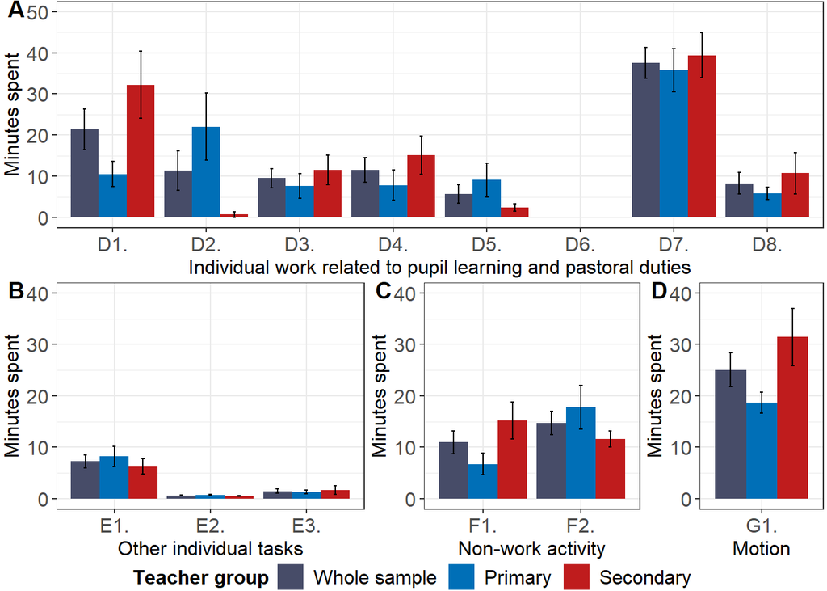

*Note.* For each teacher, total minutes spent engaging in various individual tasks related to pupil learning and pastorial duties (A), other individual tasks (B), recreation (C) and traveling through the school (D) were summed. Summary statistics were then calculated across teachers. Bars represent M whereas error bars represent SE.

### **Table**

### *Descriptive statistics on the duration of individual activities*

| Individual activity | Whole sample (N = 18) | Primary teachers (n = 9) | Secondary teachers (n = 9) |
| --- | --- | --- | --- |
| Individual work related to pupil learning and pastoral duties |  |  |  |
| D1. Lesson planning and reviewing | 21.37 (21.12) [0; 71.1] | 10.53 (9.04) [0; 22.22] | 32.22 (24.52) [1.1; 71.1] |
| D2. Written marking | 11.37 (20.13) [0; 69.4] | 22.06 (24.5) [0; 69.4] | 0.68 (1.86) [0; 5.63] |
| D3. Reviewing and uploading assessment data | 9.54 (9.87) [0; 30.03] | 7.58 (8.92) [0; 22.85] | 11.49 (10.91) [0; 30.03] |
| D4. Engaging with academic, pastoral or SEND reports and other documents | 11.45 (12.71) [0; 43.35] | 7.8 (10.99) [0; 28.48] | 15.1 (13.87) [0; 43.35] |
| D5. Other administrative tasks | 5.7 (9.36) [0; 38.9] | 9.05 (12.4) [0.03; 38.9] | 2.35 (2.64) [0; 6.72] |
| D6. Self-study and professional development | 0 (0) [0; 0] | 0 (0) [0; 0] | 0 (0) [0; 0] |
| D7. Physical resource management | 37.59 (15.75) [9.08; 65.55] | 35.79 (15.81) [9.08; 63.65] | 39.38 (16.43) [19.78; 65.55] |
| D8. Tech, computer and laptop other or unobservable activity | 8.29 (11.04) [0; 48.67] | 5.84 (4.44) [0; 13.62] | 10.74 (15.03) [0; 48.67] |
| D. Individual work related to pupil learning and pastoral duties | 105.3 (41.05) [27.43; 188.38] | 98.64 (38.33) [27.43; 151.07] | 111.96 (44.86) [46.07; 188.38] |
| Other individual tasks |  |  |  |
| E1. Cleaning/tidying classroom or school | 7.23 (5.18) [0.83; 18.97] | 8.2 (5.97) [1.12; 18.97] | 6.26 (4.39) [0.83; 14.53] |
| E2. Signing in and out of building | 0.61 (0.34) [0; 1.68] | 0.71 (0.38) [0.43; 1.68] | 0.5 (0.27) [0; 1.02] |
| E3. Managing issues with technology | 1.46 (1.94) [0; 6.9] | 1.3 (1.2) [0; 3.65] | 1.62 (2.55) [0; 6.9] |
| E. Other individual tasks | 9.3 (5.25) [1.32; 20.37] | 10.22 (6.01) [1.55; 20.37] | 8.39 (4.53) [1.32; 16.38] |
| Non-work activity |  |  |  |
| F1. Rest | 10.96 (9.56) [0.82; 30.32] | 6.74 (6.21) [0.82; 21.97] | 15.18 (10.74) [1.8; 30.32] |
| F2. Preparation and consumption of drink and/or food | 14.71 (9.85) [1.58; 41.98] | 17.8 (12.73) [1.58; 41.98] | 11.62 (4.74) [5.63; 18.93] |
| F2A. Restorative food and drink activity | 11.06 (7.71) [0; 26.98] | 12.59 (9.89) [0; 26.98] | 9.53 (4.82) [1.9; 15.83] |
| F2B. Non-restorative food and drink activity | 3.65 (4.7) [0; 17.47] | 5.2 (6.08) [0; 17.47] | 2.09 (2.15) [0; 6.4] |
| Restorative non-work activity | 22.02 (10.63) [8; 43.92] | 19.33 (8.05) [8.32; 31.3] | 24.71 (12.61) [8; 43.92] |
| Non-restorative non-work activity | 3.65 (4.7) [0; 17.47] | 5.2 (6.08) [0; 17.47] | 2.09 (2.15) [0; 6.4] |
| F. Non-work activity | 25.67 (11.18) [8.25; 45.85] | 24.54 (10.43) [11.63; 45.68] | 26.81 (12.4) [8.25; 45.85] |
| Motion |  |  |  |
| G1. Travel time between locations in or out of school | 25.05 (13.87) [0; 57.3] | 18.64 (6.06) [11.05; 27.77] | 31.45 (16.73) [0; 57.3] |

### **Table**

### *Descriptive statistics on the frequency of individual activities*

| Individual activity | Whole sample (N = 18) | Primary teachers (n = 9) | Secondary teachers (n = 9) |
| --- | --- | --- | --- |
| Individual work related to pupil learning and pastoral duties |  |  |  |
| D1. Lesson planning and reviewing | 6.94 (5.49) [0; 22] | 5.33 (4.42) [0; 13] | 8.56 (6.23) [1; 22] |
| D2. Written marking | 4.94 (7.69) [0; 24] | 9.67 (8.67) [0; 24] | 0.22 (0.44) [0; 1] |
| D3. Reviewing and uploading assessment data | 6 (7.15) [0; 23] | 5.22 (5.56) [0; 13] | 6.78 (8.73) [0; 23] |
| D4. Engaging with academic, pastoral or SEND reports and other documents | 3 (3.24) [0; 11] | 2.67 (3.61) [0; 11] | 3.33 (3) [0; 10] |
| D5. Other administrative tasks | 3.94 (4.26) [0; 15] | 5.44 (5.08) [1; 15] | 2.44 (2.79) [0; 8] |
| D6. Self-study and professional development | 0 (0) [0; 0] | 0 (0) [0; 0] | 0 (0) [0; 0] |
| D7. Physical resource management | 23.56 (11.63) [9; 45] | 25.89 (12.14) [9; 45] | 21.22 (11.3) [9; 45] |
| D8. Tech, computer and laptop other or unobservable activity | 5.22 (3.78) [0; 12] | 4.78 (3.7) [0; 10] | 5.67 (4.03) [0; 12] |
| D. Individual work related to pupil learning and pastoral duties | 53.61 (22.83) [20; 87] | 59 (24.25) [23; 87] | 48.22 (21.31) [20; 78] |
| Other individual tasks |  |  |  |
| E1. Cleaning/tidying classroom or school | 7.94 (5.77) [1; 22] | 9.33 (7.26) [1; 22] | 6.56 (3.71) [1; 12] |
| E2. Signing in and out of building | 1.78 (0.65) [0; 3] | 1.78 (0.67) [1; 3] | 1.78 (0.67) [0; 2] |
| E3. Managing issues with technology | 1.83 (2.43) [0; 10] | 1.56 (1.24) [0; 3] | 2.11 (3.3) [0; 10] |
| E. Other individual tasks | 11.56 (5.66) [2; 24] | 12.67 (6.87) [2; 24] | 10.44 (4.25) [3; 16] |
| Non-work activity |  |  |  |
| F1. Rest | 4.72 (3.36) [1; 13] | 4 (2.4) [1; 8] | 5.44 (4.13) [1; 13] |
| F2. Preparation and consumption of drink and/or food | 7.22 (4.36) [1; 17] | 6.89 (3.86) [2; 15] | 7.56 (5.03) [1; 17] |
| F2A. Restorative food and drink activity | 5.61 (3.93) [0; 14] | 5.11 (3.3) [0; 12] | 6.11 (4.62) [1; 14] |
| F2B. Non-restorative food and drink activity | 4.28 (3.27) [0; 11] | 4.56 (3.36) [0; 11] | 4 (3.35) [0; 11] |
| Restorative non-work activity | 10.33 (5.98) [3; 27] | 9.11 (3.52) [5; 17] | 11.56 (7.76) [3; 27] |
| Non-restorative non-work activity | 4.28 (3.27) [0; 11] | 4.56 (3.36) [0; 11] | 4 (3.35) [0; 11] |
| F. Non-work activity | 11.94 (6.04) [3; 26] | 10.89 (4.54) [5; 20] | 13 (7.38) [3; 26] |
| Motion |  |  |  |
| G1. Travel time between locations in or out of school | 27 (10.6) [0; 49] | 26.56 (5.29) [17; 33] | 27.44 (14.5) [0; 49] |

# Location

### **Figure**

### *Breakdown of teacher-aggregated total minutes spent at various locations*

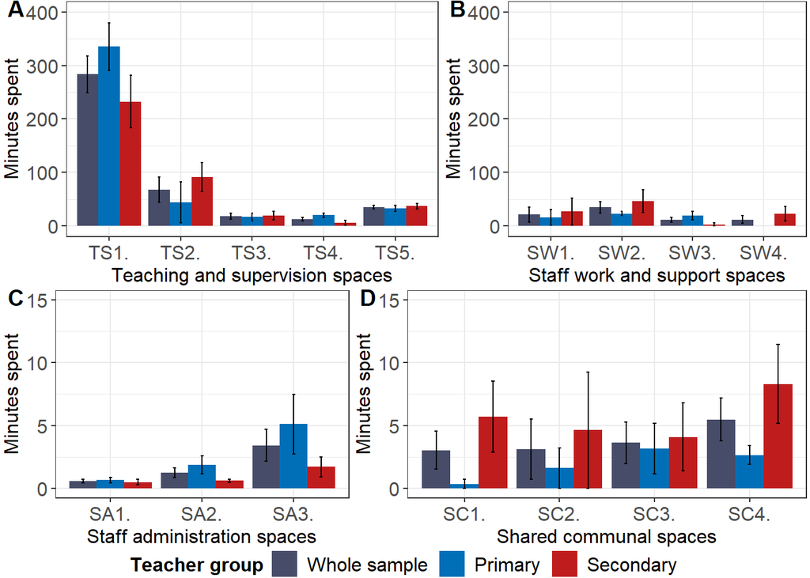

*Note.* For each teacher, total minutes spent at various locations were summed. This includes teaching and supervision spaces (A), staff work and support spaces (B), staff administration spaces (C) and shared communal spaces (D). Summary statistics were then calculated across teachers. Bars represent M whereas error bars represent SE.

### **Table**

### *Descriptive statistics on the time spent in various locations*

| Label | Whole sample (N = 18) | Primary teachers (n = 9) | Secondary teachers (n = 9) |
| --- | --- | --- | --- |
| Teaching and supervision spaces |  |  |  |
| TS1. Main classroom | 283.62 (146.65) [0; 460.7] | 335.15 (134.43) [11.15; 460.7] | 232.1 (147.16) [0; 404.45] |
| TS2. Other classroom | 67.33 (100) [0.7; 350.68] | 43.47 (115.33) [0.7; 350.68] | 91.19 (81.67) [3.32; 275.15] |
| TS3. School hall | 18.04 (22) [0; 52.35] | 16.54 (21.31) [0; 49.13] | 19.54 (23.87) [0; 52.35] |
| TS4. Playground | 12.59 (14.05) [0; 39.38] | 19.84 (11.65) [1.85; 37.97] | 5.34 (12.87) [0; 39.38] |
| TS5. Corridor | 34.74 (16.06) [13.78; 69.53] | 32.82 (17.41) [13.78; 69.53] | 36.67 (15.38) [17.28; 60.68] |
| Staff work and support spaces |  |  |  |
| SW1. Senior leadership office | 20.96 (60.16) [0; 226.12] | 15.4 (44.75) [0; 134.7] | 26.51 (74.97) [0; 226.12] |
| SW2. Staff/departmental room | 34.3 (46.61) [0; 206.85] | 22.55 (12.08) [0; 36.53] | 46.06 (64.5) [0; 206.85] |
| SW3. Meeting/PPA room | 10.86 (19.52) [0; 60.42] | 19.18 (24.41) [0; 60.42] | 2.55 (7.64) [0; 22.92] |
| SW4. Pastoral office | 11.32 (30.57) [0; 104.13] | 0 (0) [0; 0] | 22.64 (41.2) [0; 104.13] |
| Staff administration spaces |  |  |  |
| SA1. Administrative office | 0.57 (0.68) [0; 2.03] | 0.64 (0.7) [0; 1.6] | 0.5 (0.7) [0; 2.03] |
| SA2. Reception | 1.23 (1.62) [0; 6.92] | 1.85 (2.14) [0; 6.92] | 0.61 (0.38) [0; 1.27] |
| SA3. Reprographics | 3.41 (5.44) [0; 20.2] | 5.12 (7.11) [0; 20.2] | 1.71 (2.42) [0; 6.35] |
| Shared communal spaces |  |  |  |
| SC1. Canteen | 3.03 (6.45) [0; 25.17] | 0.35 (1.04) [0; 3.13] | 5.7 (8.43) [0; 25.17] |
| SC2. School library | 3.12 (10.21) [0; 41.68] | 1.61 (4.83) [0; 14.48] | 4.63 (13.89) [0; 41.68] |
| SC3. School grounds | 3.62 (6.99) [0; 25.58] | 3.16 (6.1) [0; 15.82] | 4.09 (8.13) [0; 25.58] |
| SC4. Other location | 5.48 (7.21) [0; 30.8] | 2.65 (2.2) [0; 6.23] | 8.31 (9.36) [0; 30.8] |

### **Table**

### *Descriptive statistics on the frequency of being at various locations*

| Label | Whole sample (N = 18) | Primary teachers (n = 9) | Secondary teachers (n = 9) |
| --- | --- | --- | --- |
| Teaching and supervision spaces |  |  |  |
| TS1. Main classroom | 10.89 (7.47) [0; 31] | 15.22 (7.5) [3; 31] | 6.56 (4.48) [0; 11] |
| TS2. Other classroom | 5.5 (5.54) [1; 18] | 4.33 (5) [1; 17] | 6.67 (6.1) [1; 18] |
| TS3. School hall | 1.28 (2.02) [0; 7] | 1.78 (2.54) [0; 7] | 0.78 (1.3) [0; 4] |
| TS4. Playground | 2.72 (2.42) [0; 8] | 4.11 (2.03) [1; 8] | 1.33 (2) [0; 6] |
| TS5. Corridor | 31.28 (9.58) [20; 50] | 32.67 (7.71) [23; 50] | 29.89 (11.45) [20; 46] |
| Staff work and support spaces |  |  |  |
| SW1. Senior leadership office | 1.89 (4.61) [0; 18] | 1.33 (2.96) [0; 9] | 2.44 (5.98) [0; 18] |
| SW2. Staff/departmental room | 3.89 (3.83) [0; 14] | 2.56 (2.65) [0; 8] | 5.22 (4.49) [0; 14] |
| SW3. Meeting/PPA room | 0.28 (0.46) [0; 1] | 0.44 (0.53) [0; 1] | 0.11 (0.33) [0; 1] |
| SW4. Pastoral office | 1.22 (3.25) [0; 11] | 0 (0) [0; 0] | 2.44 (4.36) [0; 11] |
| Staff administration spaces |  |  |  |
| SA1. Administrative office | 0.61 (0.7) [0; 2] | 0.67 (0.71) [0; 2] | 0.56 (0.73) [0; 2] |
| SA2. Reception | 1.61 (0.85) [0; 3] | 1.67 (1) [0; 3] | 1.56 (0.73) [0; 2] |
| SA3. Reprographics | 1.44 (1.65) [0; 5] | 2 (1.94) [0; 5] | 0.89 (1.17) [0; 3] |
| Shared communal spaces |  |  |  |
| SC1. Canteen | 0.44 (0.62) [0; 2] | 0.22 (0.67) [0; 2] | 0.67 (0.5) [0; 1] |
| SC2. School library | 0.17 (0.38) [0; 1] | 0.22 (0.44) [0; 1] | 0.11 (0.33) [0; 1] |
| SC3. School grounds | 2.11 (3.58) [0; 15] | 0.89 (1.69) [0; 5] | 3.33 (4.58) [0; 15] |
| SC4. Other location | 1.83 (1.47) [0; 4] | 1.67 (1.41) [0; 4] | 2 (1.58) [0; 4] |

# Multitasking

|  | Whole sample (N = 18) | Primary teachers (n = 9) | Secondary teachers (n = 9) |
| --- | --- | --- | --- |
| Individual single-task | 105.66 (39.71) [33.48; 177.83] | 87.06 (29.85) [33.48; 121.88] | 124.26 (41) [59.02; 177.83] |
| Interaction single-task | 337.93 (46.78) [262.48; 424.7] | 355.32 (37.92) [314.47; 424.7] | 320.54 (50.32) [262.48; 413.82] |
| Multi-task | 59.65 (21.55) [21.8; 105.25] | 64.97 (15.94) [40.87; 83.37] | 54.34 (25.87) [21.8; 105.25] |
| No task | 12.88 (10.83) [1.15; 34] | 13.59 (11.64) [2.47; 34] | 12.17 (10.6) [1.15; 28.42] |
| Interaction task | 397.58 (53.05) [291.22; 506.32] | 420.29 (47.11) [359.05; 506.32] | 374.88 (51) [291.22; 450.13] |
| Individual task | 165.32 (46.05) [88.62; 264.32] | 152.04 (33.49) [88.62; 194.17] | 178.6 (54.66) [90.45; 264.32] |

# Task-switching

Count of interruptions per day and per hour

| Phase | mean_per_day | sd_per_day | min_per_day | max_per_day | SE_per_day | mean_per_hour | sd_per_hour | min_per_hour | max_per_hour | SE_per_hour |
| --- | --- | --- | --- | --- | --- | --- | --- | --- | --- | --- |
| Whole sample | 92.28 | 35.55 | 46 | 143 | 8.38 | 10.68 | 4.05 | 5.61 | 16.96 | 0.95 |
| Primary | 99.00 | 36.28 | 46 | 143 | 12.09 | 11.34 | 3.99 | 5.61 | 16.43 | 1.33 |
| Secondary | 85.56 | 35.60 | 49 | 137 | 11.87 | 10.01 | 4.23 | 5.61 | 16.96 | 1.41 |

Duration of between tasks

| mean_mins | sd_mins | min_mins | max_mins |
| --- | --- | --- | --- |
| 0.94 | 1.32 | 0.03 | 9.93 |

# Appendix

## Time and location of work-related conversations

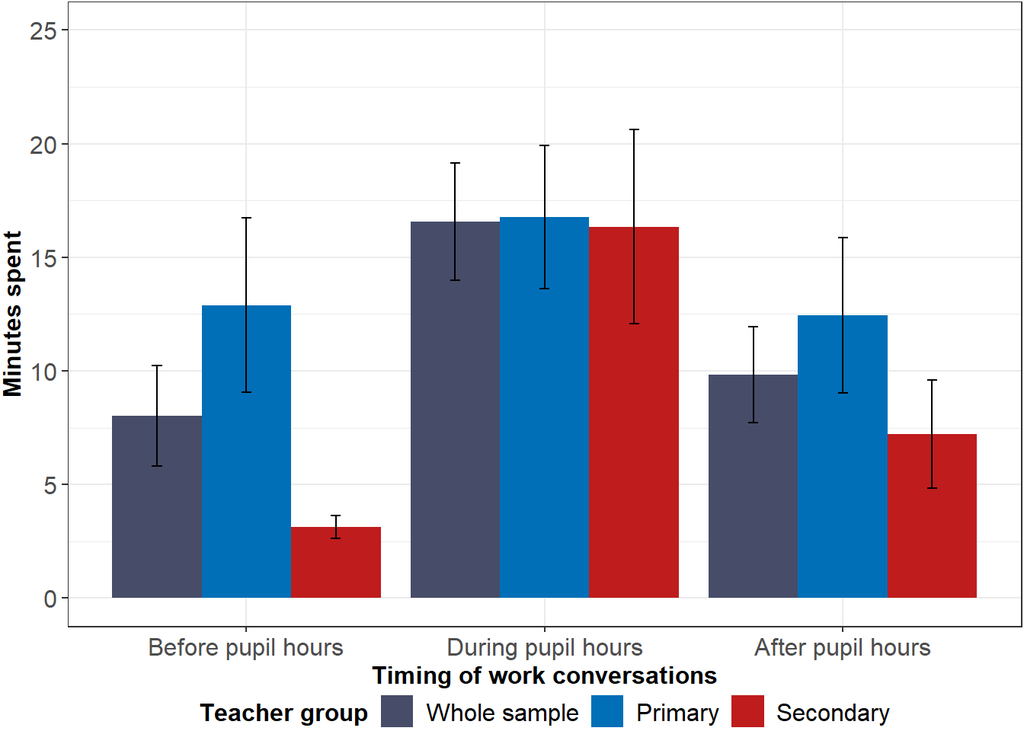

*Note.* For each teacher, total minutes spent engaging in work-related conversations with colleagues were summed. Summary statistics were then calculated across teachers. Bars represent M whereas error bars represent SE.

| Timing | Whole sample (N = 18) | Primary teachers (n = 9) | Secondary teachers (n = 9) |
| --- | --- | --- | --- |
| Duration |  |  |  |
| Before pupil hours | 8.01 (9.41) [0.35; 35.62] | 12.9 (11.51) [1.32; 35.62] | 3.13 (1.47) [0.35; 4.8] |
| During pupil hours | 16.56 (10.92) [1.42; 44.33] | 16.78 (9.44) [7.02; 33.18] | 16.34 (12.82) [1.42; 44.33] |
| After pupil hours | 9.83 (8.98) [0.83; 37.42] | 12.44 (10.24) [3.62; 37.42] | 7.21 (7.15) [0.83; 22.05] |
| Frequency |  |  |  |
| Before pupil hours | 7.78 (8.36) [1; 37] | 10.78 (11.07) [2; 37] | 4.78 (2.44) [1; 9] |
| During pupil hours | 21.06 (13.8) [5; 51] | 23.44 (14.71) [11; 51] | 18.67 (13.25) [5; 43] |
| After pupil hours | 6.22 (4.35) [1; 16] | 8.33 (4.42) [3; 16] | 4.11 (3.26) [1; 10] |

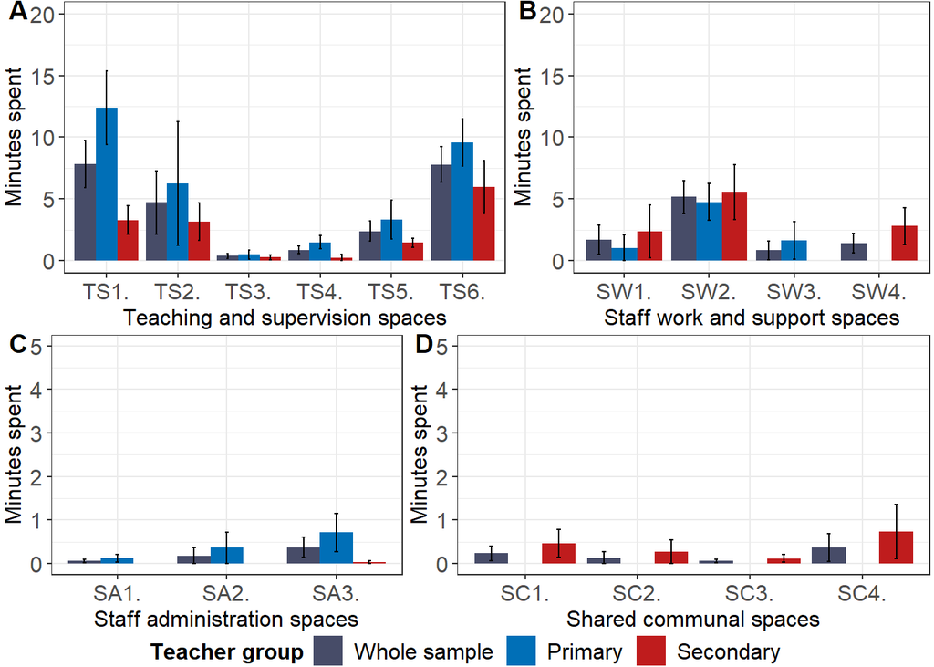

| Location | Whole sample (N = 18) | Primary teachers (n = 9) | Secondary teachers (n = 9) |
| --- | --- | --- | --- |
| Duration |  |  |  |
| SA1. Administrative office | 0.06 (0.18) [0; 0.67] | 0.12 (0.25) [0; 0.67] | 0 (0) [0; 0] |
| SA2. Reception | 0.18 (0.76) [0; 3.23] | 0.36 (1.08) [0; 3.23] | 0 (0) [0; 0] |
| SA3. Reprographics | 0.37 (0.97) [0; 3.9] | 0.71 (1.31) [0; 3.9] | 0.03 (0.09) [0; 0.27] |
| SC1. Canteen | 0.23 (0.69) [0; 2.85] | 0 (0) [0; 0] | 0.47 (0.95) [0; 2.85] |
| SC2. School library | 0.13 (0.57) [0; 2.42] | 0 (0) [0; 0] | 0.27 (0.81) [0; 2.42] |
| SC3. School grounds | 0.06 (0.18) [0; 0.65] | 0 (0) [0; 0] | 0.12 (0.24) [0; 0.65] |
| SC4. Other location | 0.37 (1.32) [0; 5.63] | 0 (0) [0; 0] | 0.73 (1.85) [0; 5.63] |
| SW1. Senior leadership office | 1.69 (4.95) [0; 19.47] | 1.03 (3.1) [0; 9.3] | 2.35 (6.44) [0; 19.47] |
| SW2. Staff/departmental room | 5.15 (5.57) [0; 19.28] | 4.76 (4.48) [0; 13.03] | 5.55 (6.74) [0; 19.28] |
| SW3. Meeting/PPA room | 0.82 (3.25) [0; 13.82] | 1.64 (4.58) [0; 13.82] | 0 (0) [0; 0] |
| SW4. Pastoral office | 1.4 (3.38) [0; 11.23] | 0 (0) [0; 0] | 2.79 (4.46) [0; 11.23] |
| TS1. Main classroom | 7.83 (8.07) [0; 28.7] | 12.37 (8.97) [0.48; 28.7] | 3.29 (3.39) [0; 9.97] |
| TS2. Other classroom | 4.71 (10.85) [0; 45.8] | 6.25 (14.97) [0; 45.8] | 3.16 (4.52) [0; 14.05] |
| TS3. School hall | 0.38 (0.86) [0; 3.15] | 0.5 (1.09) [0; 3.15] | 0.25 (0.6) [0; 1.8] |
| TS4. Playground | 0.86 (1.37) [0; 3.95] | 1.47 (1.62) [0; 3.95] | 0.25 (0.74) [0; 2.22] |
| TS5. Corridor | 2.38 (3.43) [0; 15.3] | 3.32 (4.69) [0.23; 15.3] | 1.44 (1.03) [0; 3] |
| TS6. More than one location | 7.78 (6.12) [0; 20.57] | 9.57 (5.73) [2.33; 20.57] | 5.99 (6.3) [0; 17.2] |
| Frequency |  |  |  |
| SA1. Administrative office | 0.11 (0.32) [0; 1] | 0.22 (0.44) [0; 1] | 0 (0) [0; 0] |
| SA2. Reception | 0.06 (0.24) [0; 1] | 0.11 (0.33) [0; 1] | 0 (0) [0; 0] |
| SA3. Reprographics | 0.56 (1.15) [0; 4] | 1 (1.5) [0; 4] | 0.11 (0.33) [0; 1] |
| SC1. Canteen | 0.33 (0.84) [0; 3] | 0 (0) [0; 0] | 0.67 (1.12) [0; 3] |
| SC2. School library | 0.06 (0.24) [0; 1] | 0 (0) [0; 0] | 0.11 (0.33) [0; 1] |
| SC3. School grounds | 0.28 (0.96) [0; 4] | 0 (0) [0; 0] | 0.56 (1.33) [0; 4] |
| SC4. Other location | 0.39 (1.04) [0; 4] | 0 (0) [0; 0] | 0.78 (1.39) [0; 4] |
| SW1. Senior leadership office | 1.39 (3.88) [0; 13] | 1.22 (3.67) [0; 11] | 1.56 (4.3) [0; 13] |
| SW2. Staff/departmental room | 3.39 (3.85) [0; 16] | 2.33 (2.06) [0; 6] | 4.44 (4.98) [0; 16] |
| SW3. Meeting/PPA room | 0.28 (0.96) [0; 4] | 0.56 (1.33) [0; 4] | 0 (0) [0; 0] |
| SW4. Pastoral office | 1.28 (3.85) [0; 16] | 0 (0) [0; 0] | 2.56 (5.27) [0; 16] |
| TS1. Main classroom | 8.28 (7.18) [0; 25] | 13 (7.23) [2; 25] | 3.56 (2.7) [0; 9] |
| TS2. Other classroom | 5.06 (11.88) [0; 51] | 6.89 (16.62) [0; 51] | 3.22 (3.99) [0; 13] |
| TS3. School hall | 1.06 (2.41) [0; 9] | 1.22 (2.99) [0; 9] | 0.89 (1.83) [0; 5] |
| TS4. Playground | 2.17 (3.49) [0; 12] | 3.67 (4.09) [0; 12] | 0.67 (2) [0; 6] |
| TS5. Corridor | 4.83 (3.42) [0; 12] | 5.22 (3.87) [1; 12] | 4.44 (3.09) [0; 10] |
| TS6. More than one location | 5.56 (3.58) [0; 15] | 7.11 (3.48) [3; 15] | 4 (3.12) [0; 10] |

## Estimated vs. observed time

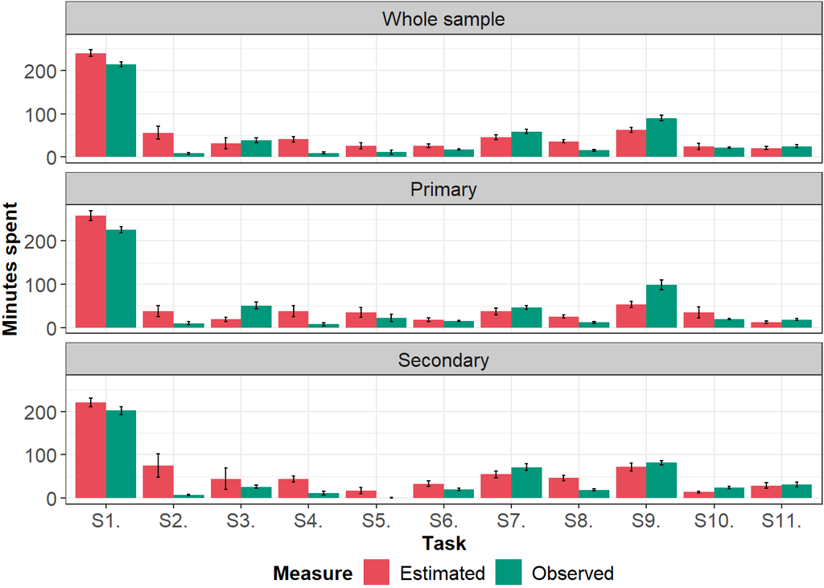

[output not shown]